# Data mining exercise

# Introduction

Your collaborator has made a CAGE experiment using 7 different tissues. As a remainder, CAGE tags are 20-21 nt long tags mapping to the genome. We often cluster CAGE tags that are close to one another on the genome to a “tag cluster”. A tag cluster can then have several tags from one or several tissues.

One can view these CAGE tag clusters as being “core promoters” in the sense that they are measuring the activity and location of a core promoter.

The data file `htbinf_cage_tpms` shows the CAGE tag clusters as rows, and tissues as columns. The cell values are the TPMs from the given tissue in the cluster. There are three additional columns: the tag cluster ID, the location of the cluster in mm8 and the strand of the cluster. The collaborator now wants to know:

**1. How many types of core promoters are there in terms of tissue expression patterns, and what expression patterns are these?**

```r
library(tidyverse)
library(viridis)
cage_data <- read_tsv("htbinf_cage_tpms.txt")
cage_data
```

```
## # A tibble: 1,000 x 10
##    tc_id     location           strand   cer   emb   liv   lun   mac   som   vis
##    <chr>     <chr>              <chr>  <dbl> <dbl> <dbl> <dbl> <dbl> <dbl> <dbl>
##  1 C13F574B~ chr13:91536205-91~ F      11.8   0    3.28  0.770  0     4.79  8.60
##  2 C3F83AF2~ chr3:138080827-13~ F      11.8   3.16 3.28  5.39   0     9.57  8.60
##  3 C14R3079~ chr14:50827439-50~ R       7.90  3.16 4.92  5.39   0     9.57 17.2
##  4 C5R67B87~ chr5:108758880-10~ R      11.8   3.16 4.92  5.39   0     9.57  8.60
##  5 CXF7D12F~ chrX:131149608-13~ F      11.8   3.16 4.92  5.39   0     9.57  8.60
##  6 C7F5DF20~ chr7:98508980-985~ F      11.8   3.16 4.92  5.39   0     9.57  8.60
##  7 C7R3916D~ chr7:59862371-598~ R      11.8   3.16 4.92  5.39   0     9.57  8.60
##  8 C5F20BAD~ chr5:34319786-343~ F      11.8   3.16 4.92  5.39   0     9.57  8.60
##  9 CMF2D67   chrM:11623-11634   F      11.8   3.16 4.92  5.39   0     9.57  8.60
## 10 C19F2CA5~ chr19:46815144-46~ F      11.8   3.16 0.821 1.54   5.89  9.57  8.60
## # ... with 990 more rows
```

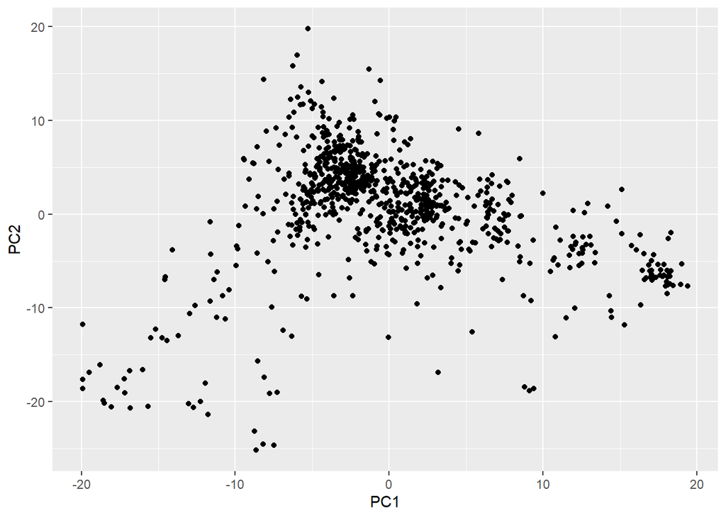

```r
cage_pca <- prcomp(cage_data[c(-1:-3)])
cage_pca$x %>%
  as.data.frame() %>%
  ggplot(aes(x=PC1, y=PC2)) + geom_point()
```

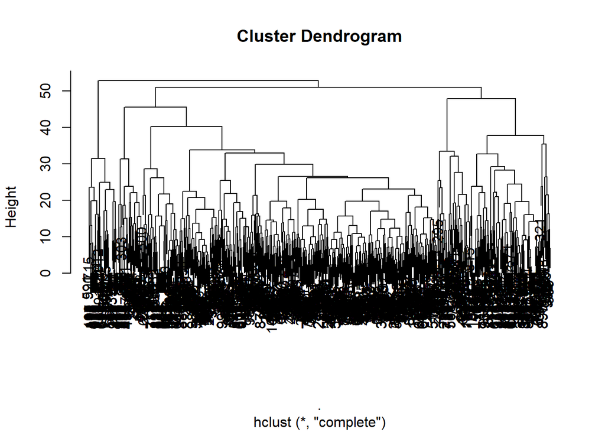

```r
cage_data[c(-1:-3)] %>%
dist(.) %>%
hclust(.)%>%
plot(.)
```

```r
cage_kmeans <- kmeans(cage_data[c(-1:-3)], 3)
cage_data$clusters <- cage_kmeans$cluster
cage_data
```

```
## # A tibble: 1,000 x 11
##    tc_id   location    strand   cer   emb   liv   lun   mac   som   vis clusters
##    <chr>   <chr>       <chr>  <dbl> <dbl> <dbl> <dbl> <dbl> <dbl> <dbl>    <int>
##  1 C13F57~ chr13:9153~ F      11.8   0    3.28  0.770  0     4.79  8.60        1
##  2 C3F83A~ chr3:13808~ F      11.8   3.16 3.28  5.39   0     9.57  8.60        1
##  3 C14R30~ chr14:5082~ R       7.90  3.16 4.92  5.39   0     9.57 17.2         1
##  4 C5R67B~ chr5:10875~ R      11.8   3.16 4.92  5.39   0     9.57  8.60        1
##  5 CXF7D1~ chrX:13114~ F      11.8   3.16 4.92  5.39   0     9.57  8.60        1
##  6 C7F5DF~ chr7:98508~ F      11.8   3.16 4.92  5.39   0     9.57  8.60        1
##  7 C7R391~ chr7:59862~ R      11.8   3.16 4.92  5.39   0     9.57  8.60        1
##  8 C5F20B~ chr5:34319~ F      11.8   3.16 4.92  5.39   0     9.57  8.60        1
##  9 CMF2D67 chrM:11623~ F      11.8   3.16 4.92  5.39   0     9.57  8.60        1
## 10 C19F2C~ chr19:4681~ F      11.8   3.16 0.821 1.54   5.89  9.57  8.60        1
## # ... with 990 more rows
```

```r
summary(cage_pca)
```

```
## Importance of components:
##                           PC1    PC2    PC3    PC4    PC5     PC6     PC7
## Standard deviation     7.9097 7.2684 6.5441 6.2371 5.7702 4.55361 4.23254
## Proportion of Variance 0.2325 0.1963 0.1592 0.1446 0.1237 0.07706 0.06658
## Cumulative Proportion  0.2325 0.4289 0.5880 0.7326 0.8564 0.93342 1.00000
```

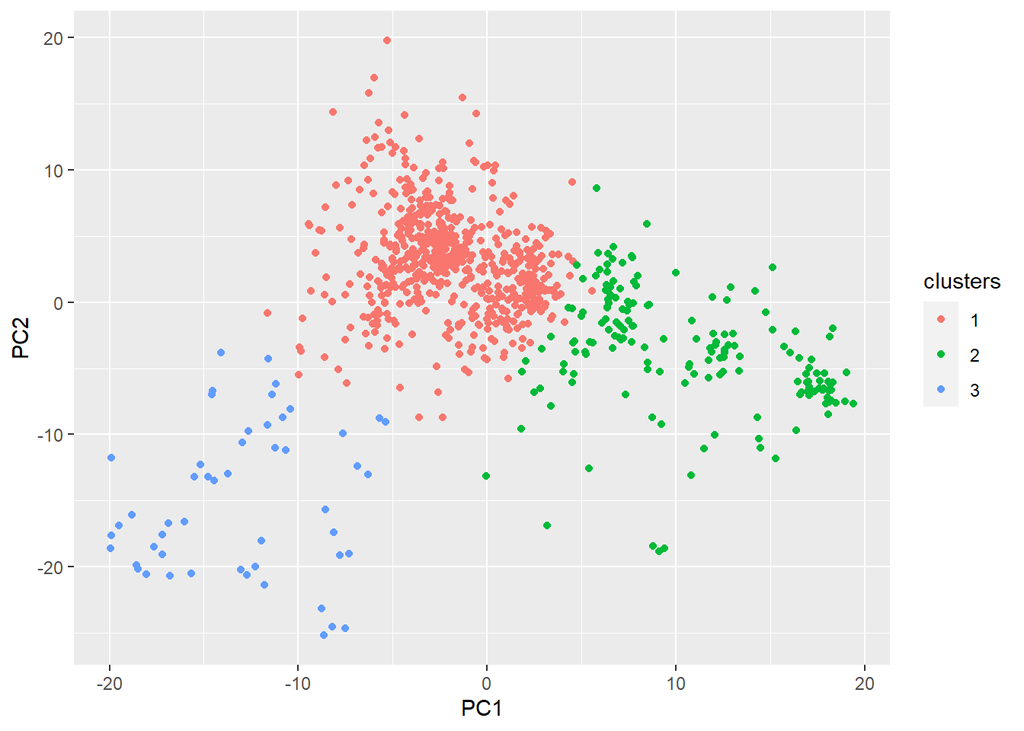

```r
cage_pca$x %>%
  as.data.frame() %>%
  mutate(clusters = as.factor(cage_kmeans$cluster)) %>%
  ggplot(aes(x=PC1, y=PC2, col=clusters)) + geom_point()
```

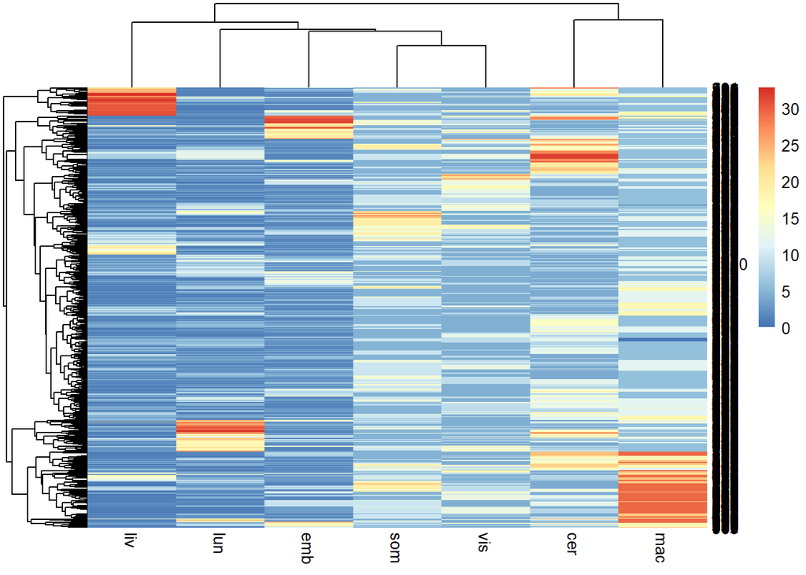

```r
library(pheatmap)
pheatmap(cage_data[c(-1:-3, -11)])
```

**2. What tissues are similar to each other in terms of promoter usage? They would really like to have this as a picture and not just “values”**

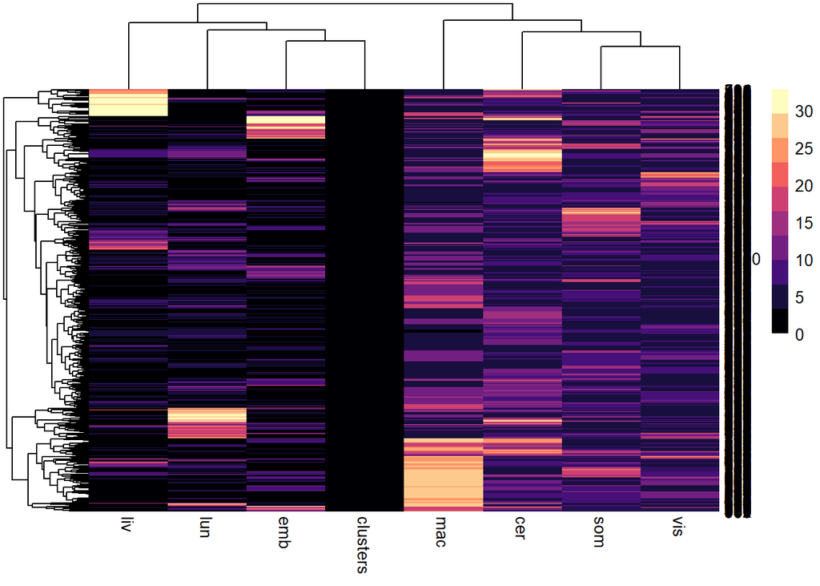

```r
library(pheatmap)
pheatmap(cage_data[c(-1:-3)], color = magma(10))
```

**3. How many tissue-specific promoters are there, per tissue and just allover? It would be very helpful to calculate two “specificity scores”: one for each tissue, and one summary score across all tissues for each promoter.**

```r
cage_data <- read_tsv("htbinf_cage_tpms.txt")
cage_data_numeric <- cage_data[4:10]
rowwise_median <- apply(cage_data_numeric, 1, function(x) median(x))
cage_diff <- cage_data_numeric - rowwise_median
cage_diff_bool <- cage_diff > 20
cage_diff_bool %>%
  as.data.frame() %>%
  mutate(Sum = apply(cage_diff_bool, 1, sum)) -> cage_diff_bool_sum
cage_diff$Sum <- cage_diff_bool_sum$Sum
cage_diff$tc_id <- cage_data$tc_id
cage_diff %>%
  mutate(Var = apply(cage_diff[c(-8,-9)], 1, function(x) var(x))) %>%
  filter(Sum == 1) %>%
  filter(cer == max(cer) | emb == max(emb) | liv == max(liv) | lun == max(lun) | mac == max(mac) | mac == max(mac) | som == max(som) | vis == max(vis)) %>%
  arrange(desc(Var))
```

```
##         cer      emb       liv       lun      mac      som      vis Sum
## 1  14.95861 -3.20420 28.035510 -4.015718  6.98431  0.00000 -0.48843   1
## 2  14.95861 -3.20420 28.035510 -4.015718  6.98431  0.00000 -0.48843   1
## 3  14.95861 -3.20420 28.035510 -4.015718  6.98431  0.00000 -0.48843   1
## 4  14.95861 -3.20420 28.035510 -4.015718  6.98431  0.00000 -0.48843   1
## 5  14.95861 -3.20420 28.035510 -4.015718  6.98431  0.00000 -0.48843   1
## 6   0.00000 -2.36713 -3.128382 -0.097560 25.47688 19.98108  4.64621   1
## 7   0.00000 -2.36713 -3.128382 -0.097560 25.47688 19.98108  4.64621   1
## 8   0.00000 -2.36713 -3.128382 -0.097560 25.47688 15.19508  0.34864   1
## 9  11.00971 -3.20420 -0.683300 27.565410  1.09917  0.00000 -0.48843   1
## 10 11.00971 -3.20420 -0.683300 27.565410  1.09917  0.00000 -0.48843   1
## 11 11.00971 -3.20420 -0.683300 27.565410  1.09917  0.00000 -0.48843   1
## 12  0.00000 -2.36713 -1.487310 -3.178648 19.59168  0.83707 21.83648   1
## 13  0.00000 -2.36713 -3.128382 -0.867830 25.47688 15.19508  4.64621   1
## 14  0.00000 -0.78535 -3.128382 -0.097560 25.47688 15.19508  0.34864   1
```

[output cut: 37 more lines]

```r
cage_data %>%
  filter(tc_id == "C1F14437FA" | tc_id == "C7F861C25B")
```

```
## # A tibble: 2 x 10
##   tc_id     location            strand   cer   emb   liv   lun   mac   som   vis
##   <chr>     <chr>               <chr>  <dbl> <dbl> <dbl> <dbl> <dbl> <dbl> <dbl>
## 1 C1F14437~ chr1:21247994-2124~ F       19.7  1.58  32.8 0.770  11.8  4.79  4.30
## 2 C7F861C2~ chr7:140624475-140~ F       19.7  1.58  32.8 0.770  11.8  4.79  4.30
```

```r
rowwise_mean <- apply(cage_data[c(-1:-3, -11)], 1, function(x) mean(x))
rowwise_median <- apply(cage_data[c(-1:-3, -11)], 1, function(x) median(x))
rowwise_var <- apply(cage_data[c(-1:-3, -11)], 1, function(x) var(x))
rowwise_min <- apply(cage_data[c(-1:-3, -11)], 1, function(x) min(x) +0.001)
cage_diff <- cage_data[c(-1:-3, -11)]-rowwise_median
cage_diff %>%
  mutate(Var = apply(cage_mean_diff, 1, function(x) var(x))) %>%
  mutate("tc_id" = cage_data$tc_id) %>%
  arrange(desc(Var)) -> cage_diff_var
cage_diff_numeric <- cage_diff_var[1:7]
cage_diff_numeric
threshold <- 20
cage_diff_boolean <- cage_diff > threshold #quantile(as.matrix(cage_numeric), 0.95)
cage_diff_boolean %>%
  as.data.frame() %>%
  mutate("tc_id" = cage_data$tc_id) %>%
  mutate(Sum = apply(cage_boolean, 1, sum)) %>%
  arrange(desc(Sum)) %>% #-> cage_diff_boolean_sum #some
  filter(Sum == 1)-> cage_diff_boolean_filtered
  #filter(Sum == 1) #-> filtered_cage_boolean
#filtered_cage_boolean <- filtered_cage_boolean[1:7]
sapply(cage_diff_boolean_filtered[1:7], sum)
sapply(cage_diff_boolean_sum[1:7], sum)
```

```r
threshold <- 20
cage_diff_var %>%
  filter(tc_id %in% cage_diff_boolean_filtered$tc_id) %>%
  gather("Tissue", "ExpDev", -Var, -tc_id) %>%
  group_by(Tissue) %>%
  summarize(Max = max(ExpDev))
  #mutate(TisSpec = ExpDev > threshold) #%>%
  #group_by(Tissue) %>%
  #summarize(Max = max(ExpDev), sum(TisSpec))
```

[output not shown]

> Pick a cutoff for variance, high variance rows are uniquely expressed in some tissues (e.g. 100) Pick a cutoff for the expression level (e.g 20) and then calculate a boolean matrix depending on this Count the booleans

```r
cage_data[c(-2:-3, -11)] %>%
  #rowwise() %>%
  #mutate(Quantile = apply(cage_data[c(-1:-3, -11)], 1, function (x) quantile(x, 0.95))) -> cage_mean
  mutate(Quantile = apply(cage_data[c(-1:-3, -11)], 1, function (x) quantile(x, 0.95))) -> cage_mean

  #as.data.frame() %>%
  #filter_if(is.numeric, any_vars(. >25))


cage_numeric <- cage_data[c(-1:-3, -11)]
cage_boolean <- cage_numeric > quantile(as.matrix(cage_numeric), 0.95)
cage_boolean %>%
  as.data.frame() %>%
  mutate("tc_id" = cage_data$tc_id) %>%
  mutate(Sum = apply(cage_boolean, 1, sum)) %>%
  filter(Sum == 1) -> filtered_cage_boolean
filtered_cage_boolean <- filtered_cage_boolean[1:7]
sapply(filtered_cage_boolean, sum)
```

```r
sapply(filtered_cage_boolean, sum)
#t.test(cage_numeric[1], cage_numeric[2])
```

[output not shown]

**4. They want to have genome browser examples of the most tissue-specific promoter for each tissue**

```r
cage_diff_var %>%
  filter(tc_id %in% cage_diff_boolean_filtered$tc_id)
  #group_by(Tissue) %>%
  #summarize(Max = max(ExpressionDeviation))
```

[output not shown]

**5 Lastly, they want a list with the 10 most tissue-specific promoters, taking all tissues into account.**

```r
pheatmap(cage_data[c(-1:-3)], color = rainbow(10))
```

[output not shown]